# Data Exploration

In this report, we will explore the data generating mechanism underlying the simulation study.

```r
# load libraries
library(ggplot2)
library(ggpubr)
library(lme4)
library(here)
library(tidyr)
library(dplyr)
# source the helper function
source(here("scripts/hamaker2020_extended/helper-functions/data-generation-centeredX.R"))
```

## Continuous X and Y

In the original simulation study by Hamaker and Muthen (2020), the authors generated data for a continuous predictor and continuous outcome with the following parameters

```r
set.seed(3859)
N<-5000 # number of clusters
n<-4 # number of observations within a cluster

########################
#### SET PARAMETER VALUES ####
########################

# PREDICTOR
sdX.within <- sqrt(1) # within-person variance
sdX.between <- sqrt(4) # between-person variance

# INTERCEPT LEVEL 2
g.00 <- 0 # Grand intercept
g.01 <- 2 # between-cluster slope
sd.u0 <- 1 # SD of residuals intercept at level 2

# SLOPE LEVEL 2
g.10 <- 1 # fixed within-cluster slope
sd.u1 <- 0 # SD of within-cluster slope at level 2

# RESIDUALS AT LEVEL 1
sd.e <- 1 # residual SD at level 1
```

We can replicate this value with a more generalized function as follows

```r
# original values in simulations of Hamaker en Muthen (2020)
data_cont_hm2020 <- glmm_data_generation(N_total = 1000, T_total = 4, predictor.type = "continuous", outcome.type = "continuous",
                                  sdX.within = sqrt(1), sdX.between = sqrt(4), g.00 = 0, g.01 = 2, sd.u0 = 1,
                                  g.10 = 1, sd.u1 = 0, sd.e = 1)
summary(data_cont_hm2020)
```

```
    Cluster            Time         X.mean.j              b0
 Min.   :   1.0   Min.   :1.00   Min.   :-5.99358   Min.   :-14.25076
 1st Qu.: 250.8   1st Qu.:1.75   1st Qu.:-1.19773   1st Qu.: -2.39310
 Median : 500.5   Median :2.50   Median : 0.02210   Median :  0.05345
 Mean   : 500.5   Mean   :2.50   Mean   : 0.04753   Mean   :  0.14480
 3rd Qu.: 750.2   3rd Qu.:3.25   3rd Qu.: 1.40868   3rd Qu.:  3.06419
 Max.   :1000.0   Max.   :4.00   Max.   : 5.91145   Max.   : 12.14204
       b1    p.X.mean.j           X                 eta
 Min.   :1   Mode:logical   Min.   :-7.76777   Min.   :-14.72385
 1st Qu.:1   NA's:4000      1st Qu.:-1.41258   1st Qu.: -2.49352
 Median :1                  Median : 0.07496   Median :  0.03185
 Mean   :1                  Mean   : 0.04814   Mean   :  0.14541
 3rd Qu.:1                  3rd Qu.: 1.57351   3rd Qu.:  3.10005
 Max.   :1                  Max.   : 6.93210   Max.   : 12.90151
       Y              p.Y          X.cluster.means        X.cent
 Min.   :-16.5103   Mode:logical   Min.   :-5.77175   Min.   :-3.02794
 1st Qu.: -2.6098   NA's:4000      1st Qu.:-1.23769   1st Qu.:-0.56041
 Median :  0.1072                  Median : 0.07529   Median :-0.02079
 Mean   :  0.1401                  Mean   : 0.04814   Mean   : 0.00000
 3rd Qu.:  3.1125                  3rd Qu.: 1.44670   3rd Qu.: 0.56146
 Max.   : 13.5506                  Max.   : 6.03483   Max.   : 3.21970
```

```r
fixef(lmer(Y ~ X.cent + X.cluster.means + (1 | Cluster), data = data_cont_hm2020))
```

```
    (Intercept)          X.cent X.cluster.means
     0.04787445      0.97655724      1.91572087
```

As we can see, the X and Y values have quite a large range of -8 to 8 and -16 to 16 respectively. As we want to ensure, for the analyses with discrete outcomes, that the eta values are not too extreme (within -3 to 3 range), we will decrease the values of the parameters. Let us also add some timepoints to enhance estimation of the cluster mean of X.

```r
data_cont <- glmm_data_generation(N_total = 1000, T_total = 20, predictor.type = "continuous", outcome.type = "continuous",
                                  sdX.within = 0.25, sdX.between = 0.5, g.00 = 0, g.01 = 1, sd.u0 = 0.7,
                                  g.10 = 0.5, sd.u1 = 0, sd.e = 0.5)
summary(data_cont)
```

```
    Cluster            Time          X.mean.j               b0
 Min.   :   1.0   Min.   : 1.00   Min.   :-1.682080   Min.   :-2.740486
 1st Qu.: 250.8   1st Qu.: 5.75   1st Qu.:-0.352390   1st Qu.:-0.567241
 Median : 500.5   Median :10.50   Median : 0.002505   Median :-0.004011
 Mean   : 500.5   Mean   :10.50   Mean   :-0.012439   Mean   :-0.009237
 3rd Qu.: 750.2   3rd Qu.:15.25   3rd Qu.: 0.313230   3rd Qu.: 0.563315
 Max.   :1000.0   Max.   :20.00   Max.   : 1.516429   Max.   : 2.585120
       b1      p.X.mean.j           X                   eta
 Min.   :0.5   Mode:logical   Min.   :-2.1295719   Min.   :-2.9338604
 1st Qu.:0.5   NA's:20000     1st Qu.:-0.3961205   1st Qu.:-0.5661364
 Median :0.5                  Median :-0.0005681   Median : 0.0006676
 Mean   :0.5                  Mean   :-0.0120329   Mean   :-0.0090337
 3rd Qu.:0.5                  3rd Qu.: 0.3688674   3rd Qu.: 0.5720018
 Max.   :0.5                  Max.   : 2.0856738   Max.   : 2.8092004
       Y               p.Y          X.cluster.means         X.cent
 Min.   :-3.848201   Mode:logical   Min.   :-1.739640   Min.   :-1.1005901
 1st Qu.:-0.674381   NA's:20000     1st Qu.:-0.351329   1st Qu.:-0.1669442
 Median : 0.004634                  Median : 0.005293   Median : 0.0002873
 Mean   :-0.011581                  Mean   :-0.012033   Mean   : 0.0000000
 3rd Qu.: 0.660404                  3rd Qu.: 0.326493   3rd Qu.: 0.1673420
 Max.   : 3.387344                  Max.   : 1.594477   Max.   : 1.0602928
```

```r
fixef(lmer(Y ~ X.cent + X.cluster.means + (1 | Cluster), data = data_cont))
```

```
    (Intercept)          X.cent X.cluster.means
  -0.0002767367    0.5180263529    0.9394629972
```

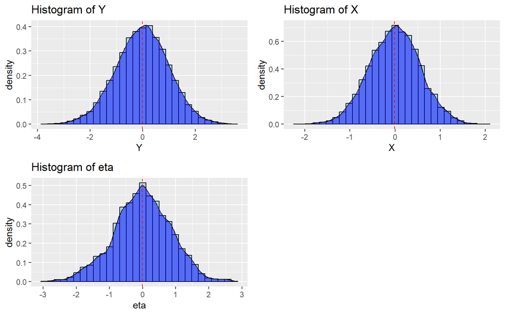

```r
# 1.1 check distributions of X and Y
p1.11 <- ggplot(data_cont, aes(x = Y)) + geom_histogram(aes(y = ..density..), bins = 30, fill = "lightblue", color = "black") +
  geom_density(alpha = 0.5, fill = "blue") + labs(title = "Histogram of Y") +
  geom_vline(xintercept = mean(data_cont$Y), linetype = "dashed", color = "red")
p1.12 <- ggplot(data_cont, aes(x = X)) + geom_histogram(aes(y = ..density..), bins = 30, fill = "lightblue", color = "black") +
  geom_density(alpha = 0.5, fill = "blue") + labs(title = "Histogram of X") +
  geom_vline(xintercept = mean(data_cont$X), linetype = "dashed", color = "red")

# 1.2 check histogram of eta
p1.2 <- ggplot(data_cont, aes(x = eta)) + geom_histogram(aes(y = ..density..), bins = 30, fill = "lightblue", color = "black") +
  geom_density(alpha = 0.5, fill = "blue") + labs(title = "Histogram of eta") +
  geom_vline(xintercept = mean(data_cont$eta), linetype = "dashed", color = "red")

# combine plots
gridExtra::grid.arrange(p1.11, p1.12, p1.2, ncol = 2)
```

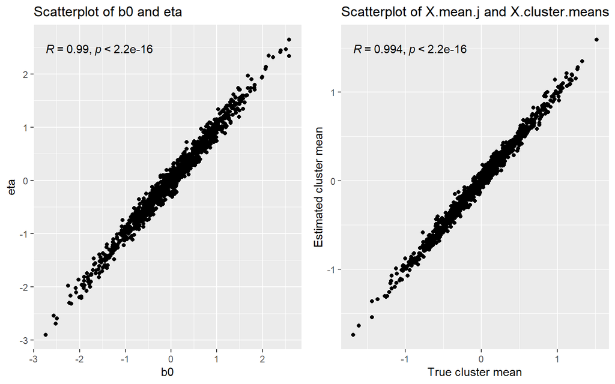

```r
# Reduce to only cluster level variables
data_cont_level2 <- data_cont %>% select(Cluster, X.cluster.means, X.mean.j, p.X.mean.j, eta, b0, b1) %>%
  distinct(Cluster, .keep_all = TRUE)

# 1.4 scatterplot of b0 and eta and X.mean.j and X.cluster.means
p1.31 <- ggplot(data_cont_level2, aes(x = b0, y = eta)) + geom_point() + labs(title = "Scatterplot of b0 and eta") + stat_cor(method = "pearson", digits = 3)
p1.32 <- ggplot(data_cont_level2, aes(x = X.mean.j, y = X.cluster.means)) + geom_point() + labs(title = "Scatterplot of X.mean.j and X.cluster.means", x = "True cluster mean", y = "Estimated cluster mean") + stat_cor(method = "pearson", digits = 3)

# combine plots
gridExtra::grid.arrange(p1.31, p1.32, ncol = 2)
```

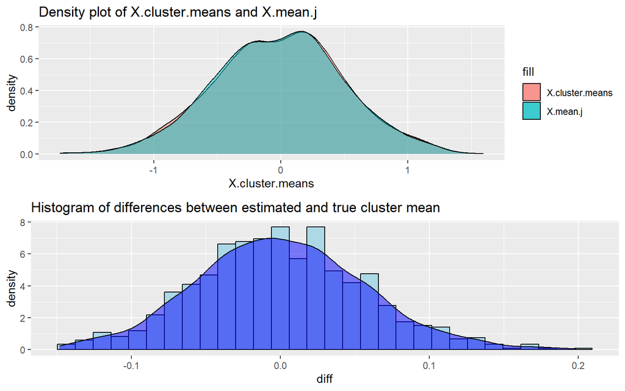

```r
# 1.3 overlaying density plots for X.cluster.means and X.mean.j
p1.41 <- ggplot(data_cont_level2, aes(x = X.cluster.means, fill = "X.cluster.means")) + geom_density(alpha = 0.5) +
  geom_density(aes(x = X.mean.j, fill = "X.mean.j"), alpha = 0.5) + labs(title = "Density plot of X.cluster.means and X.mean.j")

# compute difference between estimated and true cluster mean for each cluster
data_cont_level2$diff <- data_cont_level2$X.cluster.means - data_cont_level2$X.mean.j

# plot histogram of differences
p1.42 <- ggplot(data_cont_level2, aes(x = diff)) + geom_histogram(aes(y = ..density..), bins = 30, fill = "lightblue", color = "black") +
  geom_density(alpha = 0.5, fill = "blue") + labs(title = "Histogram of differences between estimated and true cluster mean") +
  geom_vline(xintercept = mean(data_cont$diff), linetype = "dashed", color = "red")
# combine plots
gridExtra::grid.arrange(p1.41, p1.42, nrow = 2)
```

## Binary X and Continuous Y

```r
### 2 generate binary X and continuous Y
data_binx_conty <- glmm_data_generation(N_total = 1000, T_total = 20, predictor.type = "binary", outcome.type = "continuous",
                                        sdX.within = NA, sdX.between = 0.5, g.00 = 0, g.01 = 0.6, sd.u0 = 0.7,
                                        g.10 = 0.5, sd.u1 = 0, sd.e = 0.5)
# same values as (1) but without sdX.within
summary(data_binx_conty)
```

```
    Cluster            Time          X.mean.j              b0
 Min.   :   1.0   Min.   : 1.00   Min.   :-1.80884   Min.   :-2.2077
 1st Qu.: 250.8   1st Qu.: 5.75   1st Qu.:-0.31099   1st Qu.:-0.1715
 Median : 500.5   Median :10.50   Median : 0.02785   Median : 0.3235
 Mean   : 500.5   Mean   :10.50   Mean   : 0.01763   Mean   : 0.3163
 3rd Qu.: 750.2   3rd Qu.:15.25   3rd Qu.: 0.36682   3rd Qu.: 0.7481
 Max.   :1000.0   Max.   :20.00   Max.   : 1.56453   Max.   : 2.5762
       b1        p.X.mean.j           X              eta
 Min.   :0.5   Min.   :0.1408   Min.   :0.000   Min.   :-2.4150
 1st Qu.:0.5   1st Qu.:0.4229   1st Qu.:0.000   1st Qu.:-0.1792
 Median :0.5   Median :0.5070   Median :0.000   Median : 0.3193
 Mean   :0.5   Mean   :0.5042   Mean   :0.498   Mean   : 0.3132
 3rd Qu.:0.5   3rd Qu.:0.5907   3rd Qu.:1.000   3rd Qu.: 0.7941
 Max.   :0.5   Max.   :0.8270   Max.   :1.000   Max.   : 2.9226
       Y             p.Y          X.cluster.means     X.cent
 Min.   :-3.3000   Mode:logical   Min.   :0.050   Min.   :-0.95
 1st Qu.:-0.2864   NA's:20000     1st Qu.:0.400   1st Qu.:-0.45
 Median : 0.3186                  Median :0.500   Median :-0.10
 Mean   : 0.3145                  Mean   :0.498   Mean   : 0.00
 3rd Qu.: 0.9124                  3rd Qu.:0.600   3rd Qu.: 0.45
 Max.   : 4.0806                  Max.   :0.950   Max.   : 0.95
```

```r
fixef(lmer(Y ~ X.cent + X.cluster.means + (1 | Cluster), data = data_binx_conty))
```

```
    (Intercept)          X.cent X.cluster.means
     0.08078075      0.51288590      0.46927887
```

Strange behaviour when g.01 is negative or exceeds 0.8 (with T = 20). The intercept is borrowing from the slope. Happens more with a smaller number of total timepoints T. A value of 0.6 seems to be fine.

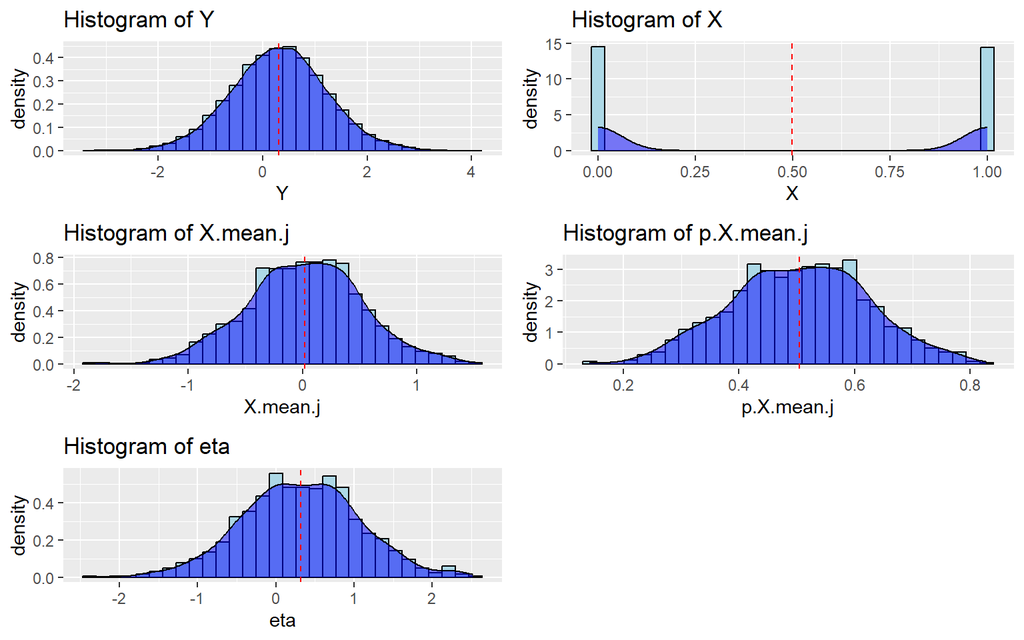

```r
# 2.1 check distributions of X and Y
p2.11 <- ggplot(data_binx_conty, aes(x = Y)) + geom_histogram(aes(y = ..density..), bins = 30, fill = "lightblue", color = "black") +
  geom_density(alpha = 0.5, fill = "blue") + labs(title = "Histogram of Y") +
  geom_vline(xintercept = mean(data_binx_conty$Y), linetype = "dashed", color = "red")
p2.12 <- ggplot(data_binx_conty, aes(x = X)) + geom_histogram(aes(y = ..density..), bins = 30, fill = "lightblue", color = "black") +
  geom_density(alpha = 0.5, fill = "blue") + labs(title = "Histogram of X") +
  geom_vline(xintercept = mean(data_binx_conty$X), linetype = "dashed", color = "red")

# Reduce to only cluster level variables
data_binx_conty_level2 <- data_binx_conty %>% select(Cluster, X.cluster.means, X.mean.j, p.X.mean.j, eta, b0, b1) %>%
  distinct(Cluster, .keep_all = TRUE)

# 2.2 histograms X.mean.j, p.X.mean.j and eta
p2.21 <- ggplot(data_binx_conty_level2, aes(x = X.mean.j)) + geom_histogram(aes(y = ..density..), bins = 30, fill = "lightblue", color = "black") +
  geom_density(alpha = 0.5, fill = "blue") + labs(title = "Histogram of X.mean.j") +
  geom_vline(xintercept = mean(data_binx_conty$X.mean.j), linetype = "dashed", color = "red")
p2.22 <- ggplot(data_binx_conty_level2, aes(x = p.X.mean.j)) + geom_histogram(aes(y = ..density..), bins = 30, fill = "lightblue", color = "black") +
  geom_density(alpha = 0.5, fill = "blue") + labs(title = "Histogram of p.X.mean.j") +
  geom_vline(xintercept = mean(data_binx_conty$p.X.mean.j), linetype = "dashed", color = "red")
p2.23 <- ggplot(data_binx_conty_level2, aes(x = eta)) + geom_histogram(aes(y = ..density..), bins = 30, fill = "lightblue", color = "black") +
  geom_density(alpha = 0.5, fill = "blue") + labs(title = "Histogram of eta") +
  geom_vline(xintercept = mean(data_binx_conty$eta), linetype = "dashed", color = "red")
# eta is nicely distributed with -3 to 3 range

# when sdX.between is large (e.g, sqrt(4)) the distribution of probabilities
# of X and Y are U/bowl shaped (higher density at the edges)
# when sdX.between is small (e.g., sqrt(0.4)) the distribution of probabilities
# of X and Y are inverted U shaped (higher density in the center)

# combine plots
gridExtra::grid.arrange(p2.11, p2.12, p2.21, p2.22, p2.23, ncol = 2)
```

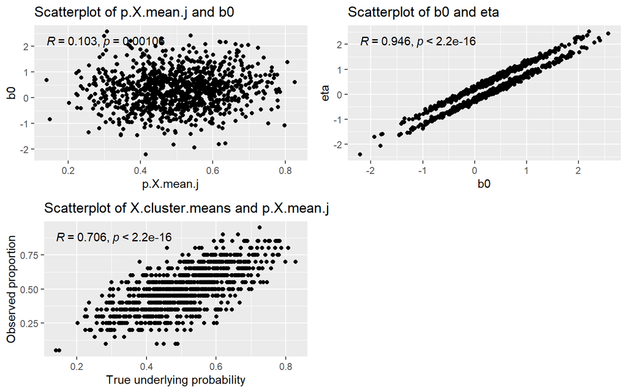

```r
# 2.3 scatterplot of p.X.mean.j and b0, b0 and eta, estimated cluster mean and p.X.mean.j
p2.31 <- ggplot(data_binx_conty_level2, aes(x = p.X.mean.j, y = b0)) + geom_point() + labs(title = "Scatterplot of p.X.mean.j and b0") + stat_cor(method = "pearson", digits = 3)

p2.32 <- ggplot(data_binx_conty_level2, aes(x = b0, y = eta)) + geom_point() + labs(title = "Scatterplot of b0 and eta") + stat_cor(method = "pearson", digits = 3)
p2.33 <- ggplot(data_binx_conty_level2, aes(x = p.X.mean.j, y = X.cluster.means)) + geom_point() + labs(title = "Scatterplot of X.cluster.means and p.X.mean.j", x = "True underlying probability", y = "Observed proportion") + stat_cor(method = "pearson", digits = 3)

# combine plots
gridExtra::grid.arrange(p2.31, p2.32, p2.33, ncol = 2)
```

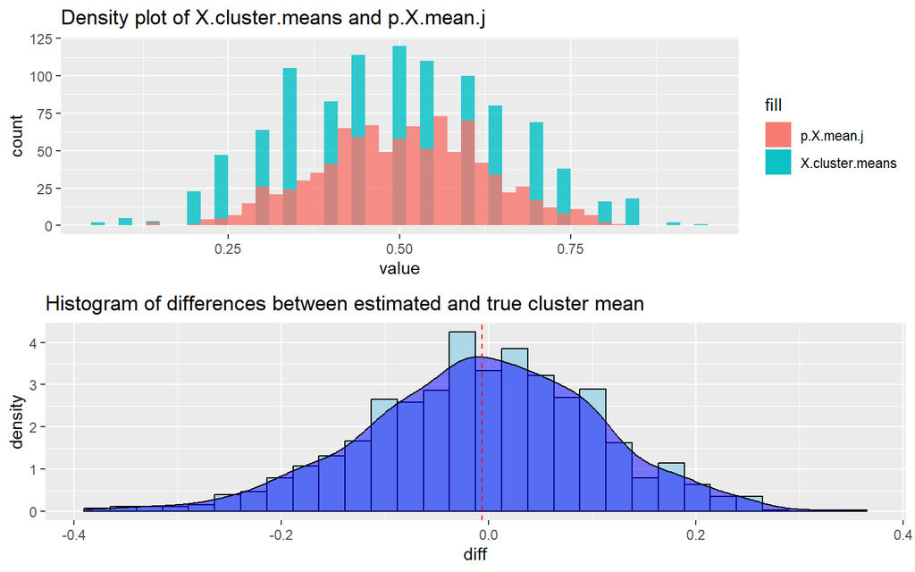

```r
# create overlapping density plots for X.cluster.means and p.X.mean.j
p2.41 <- ggplot(data_binx_conty_level2, aes(x = X.cluster.means, fill = "X.cluster.means")) + geom_histogram(alpha = 0.8, binwidth = 0.02) +
  geom_histogram(aes(x = p.X.mean.j, fill = "p.X.mean.j"), alpha = 0.8, binwidth = 0.02) + labs(title = "Density plot of X.cluster.means and p.X.mean.j", x = "value")

# compute difference between estimated and true cluster mean for each cluster
data_binx_conty_level2$diff <- data_binx_conty_level2$X.cluster.means - data_binx_conty_level2$p.X.mean.j

# plot histogram of differences
p2.42 <- ggplot(data_binx_conty_level2, aes(x = diff)) + geom_histogram(aes(y = ..density..), bins = 30, fill = "lightblue", color = "black") +
  geom_density(alpha = 0.5, fill = "blue") + labs(title = "Histogram of differences between estimated and true cluster mean") +
  geom_vline(xintercept = mean(data_binx_conty_level2$diff, na.rm = TRUE), linetype = "dashed", color = "red")

# combine plots
gridExtra::grid.arrange(p2.41, p2.42, nrow = 2)
```

Let’s now simulate the data with a more U shaped distribution for p.X.mean.j by increasing the value of sdX.between from 0.5 to 3.

```r
### 2 generate binary X and continuous Y
data_binx_conty <- glmm_data_generation(N_total = 1000, T_total = 20, predictor.type = "binary", outcome.type = "continuous",
                                        sdX.within = NA, sdX.between = 3, g.00 = 0, g.01 = 0.6, sd.u0 = 0.7,
                                        g.10 = 0.5, sd.u1 = 0, sd.e = 0.5)
# same values as (1) but without sdX.within
summary(data_binx_conty)
```

```
    Cluster            Time          X.mean.j               b0
 Min.   :   1.0   Min.   : 1.00   Min.   :-11.54527   Min.   :-2.3912
 1st Qu.: 250.8   1st Qu.: 5.75   1st Qu.: -2.08819   1st Qu.:-0.1498
 Median : 500.5   Median :10.50   Median :  0.08600   Median : 0.3154
 Mean   : 500.5   Mean   :10.50   Mean   : -0.03789   Mean   : 0.3085
 3rd Qu.: 750.2   3rd Qu.:15.25   3rd Qu.:  1.90162   3rd Qu.: 0.8008
 Max.   :1000.0   Max.   :20.00   Max.   :  8.71302   Max.   : 2.7527
       b1        p.X.mean.j              X               eta
 Min.   :0.5   Min.   :0.0000097   Min.   :0.0000   Min.   :-2.3986
 1st Qu.:0.5   1st Qu.:0.1102498   1st Qu.:0.0000   1st Qu.:-0.1684
 Median :0.5   Median :0.5214852   Median :1.0000   Median : 0.3145
 Mean   :0.5   Mean   :0.5019010   Mean   :0.5028   Mean   : 0.3089
 3rd Qu.:0.5   3rd Qu.:0.8700749   3rd Qu.:1.0000   3rd Qu.: 0.8159
 Max.   :0.5   Max.   :0.9998356   Max.   :1.0000   Max.   : 2.7606
       Y             p.Y          X.cluster.means      X.cent
 Min.   :-3.7326   Mode:logical   Min.   :0.0000   Min.   :-0.95
 1st Qu.:-0.2991   NA's:20000     1st Qu.:0.1000   1st Qu.:-0.15
 Median : 0.3150                  Median :0.5000   Median : 0.00
 Mean   : 0.3114                  Mean   :0.5028   Mean   : 0.00
 3rd Qu.: 0.9233                  3rd Qu.:0.9000   3rd Qu.: 0.15
 Max.   : 3.8337                  Max.   :1.0000   Max.   : 0.95
```

```r
fixef(lmer(Y ~ X.cent + X.cluster.means + (1 | Cluster), data = data_binx_conty))
```

```
    (Intercept)          X.cent X.cluster.means
   -0.001994355     0.479711240     0.623356540
```

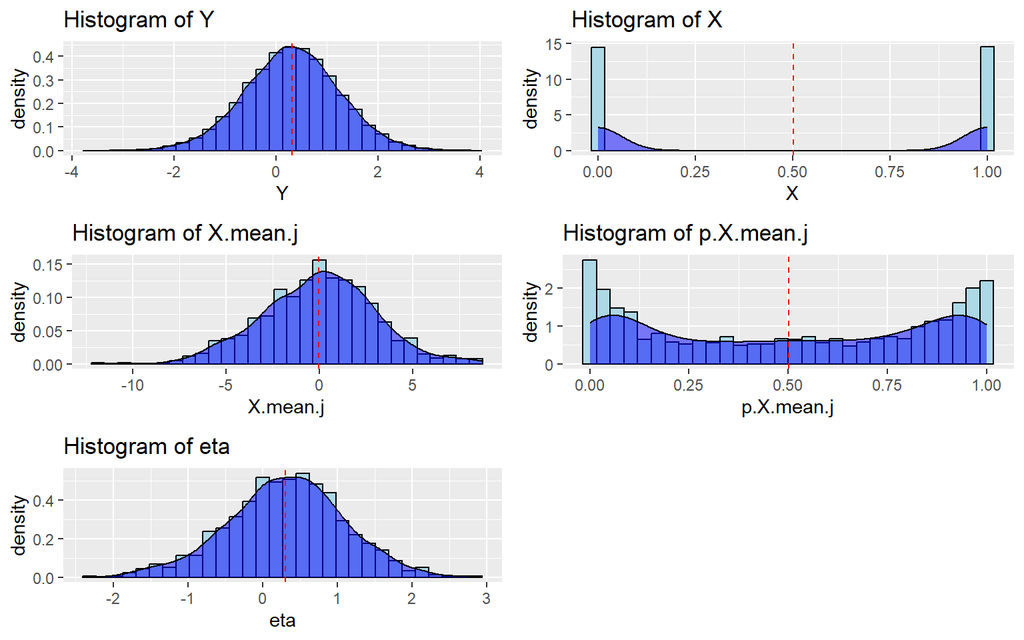

```r
# 2.1 check distributions of X and Y
p2.11 <- ggplot(data_binx_conty, aes(x = Y)) + geom_histogram(aes(y = ..density..), bins = 30, fill = "lightblue", color = "black") +
  geom_density(alpha = 0.5, fill = "blue") + labs(title = "Histogram of Y") +
  geom_vline(xintercept = mean(data_binx_conty$Y), linetype = "dashed", color = "red")
p2.12 <- ggplot(data_binx_conty, aes(x = X)) + geom_histogram(aes(y = ..density..), bins = 30, fill = "lightblue", color = "black") +
  geom_density(alpha = 0.5, fill = "blue") + labs(title = "Histogram of X") +
  geom_vline(xintercept = mean(data_binx_conty$X), linetype = "dashed", color = "red")

# Reduce to only cluster level variables
data_binx_conty_level2 <- data_binx_conty %>% select(Cluster, X.cluster.means, X.mean.j, p.X.mean.j, eta, b0, b1) %>%
  distinct(Cluster, .keep_all = TRUE)

# 2.2 histograms X.mean.j, p.X.mean.j and eta
p2.21 <- ggplot(data_binx_conty_level2, aes(x = X.mean.j)) + geom_histogram(aes(y = ..density..), bins = 30, fill = "lightblue", color = "black") +
  geom_density(alpha = 0.5, fill = "blue") + labs(title = "Histogram of X.mean.j") +
  geom_vline(xintercept = mean(data_binx_conty$X.mean.j), linetype = "dashed", color = "red")
p2.22 <- ggplot(data_binx_conty_level2, aes(x = p.X.mean.j)) + geom_histogram(aes(y = ..density..), bins = 30, fill = "lightblue", color = "black") +
  geom_density(alpha = 0.5, fill = "blue") + labs(title = "Histogram of p.X.mean.j") +
  geom_vline(xintercept = mean(data_binx_conty$p.X.mean.j), linetype = "dashed", color = "red")
p2.23 <- ggplot(data_binx_conty_level2, aes(x = eta)) + geom_histogram(aes(y = ..density..), bins = 30, fill = "lightblue", color = "black") +
  geom_density(alpha = 0.5, fill = "blue") + labs(title = "Histogram of eta") +
  geom_vline(xintercept = mean(data_binx_conty$eta), linetype = "dashed", color = "red")
# eta is nicely distributed with -3 to 3 range

# when sdX.between is large (e.g, sqrt(4)) the distribution of probabilities
# of X and Y are U/bowl shaped (higher density at the edges)
# when sdX.between is small (e.g., sqrt(0.4)) the distribution of probabilities
# of X and Y are inverted U shaped (higher density in the center)

# combine plots
gridExtra::grid.arrange(p2.11, p2.12, p2.21, p2.22, p2.23, ncol = 2)
```

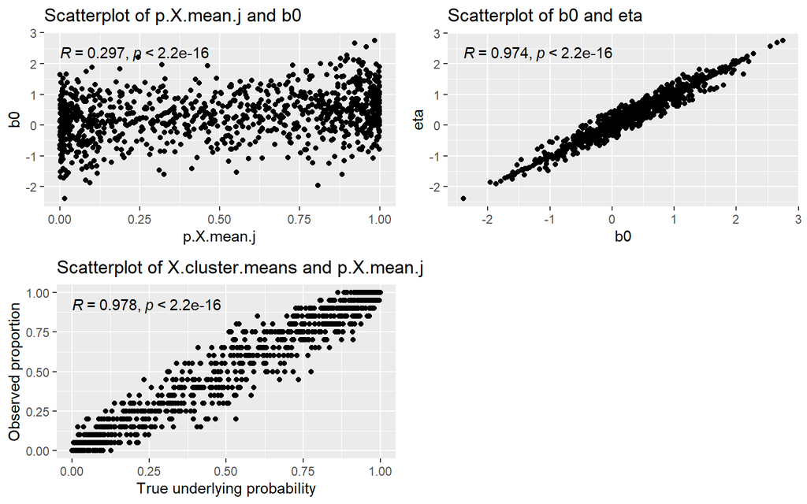

```r
# 2.3 scatterplot of p.X.mean.j and b0, b0 and eta, estimated cluster mean and p.X.mean.j
p2.31 <- ggplot(data_binx_conty_level2, aes(x = p.X.mean.j, y = b0)) + geom_point() + labs(title = "Scatterplot of p.X.mean.j and b0") + stat_cor(method = "pearson", digits = 3)

p2.32 <- ggplot(data_binx_conty_level2, aes(x = b0, y = eta)) + geom_point() + labs(title = "Scatterplot of b0 and eta") + stat_cor(method = "pearson", digits = 3)
p2.33 <- ggplot(data_binx_conty_level2, aes(x = p.X.mean.j, y = X.cluster.means)) + geom_point() + labs(title = "Scatterplot of X.cluster.means and p.X.mean.j", x = "True underlying probability", y = "Observed proportion") + stat_cor(method = "pearson", digits = 3)

# combine plots
gridExtra::grid.arrange(p2.31, p2.32, p2.33, ncol = 2)
```

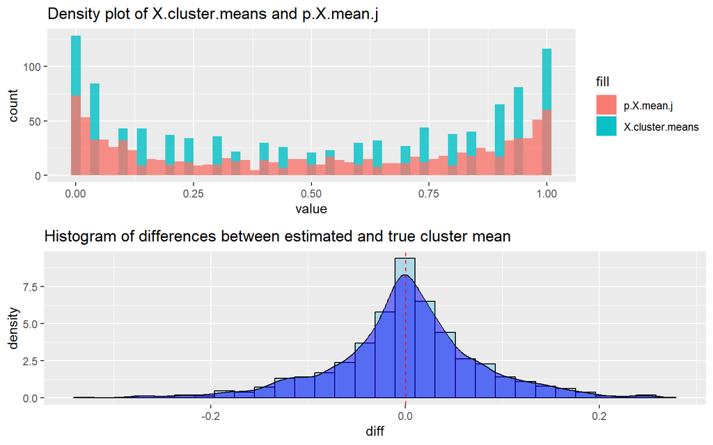

```r
# create overlapping density plots for X.cluster.means and p.X.mean.j
p2.41 <- ggplot(data_binx_conty_level2, aes(x = X.cluster.means, fill = "X.cluster.means")) + geom_histogram(alpha = 0.8, binwidth = 0.02) +
  geom_histogram(aes(x = p.X.mean.j, fill = "p.X.mean.j"), alpha = 0.8, binwidth = 0.02) + labs(title = "Density plot of X.cluster.means and p.X.mean.j", x = "value")

# compute difference between estimated and true cluster mean for each cluster
data_binx_conty_level2$diff <- data_binx_conty_level2$X.cluster.means - data_binx_conty_level2$p.X.mean.j

# plot histogram of differences
p2.42 <- ggplot(data_binx_conty_level2, aes(x = diff)) + geom_histogram(aes(y = ..density..), bins = 30, fill = "lightblue", color = "black") +
  geom_density(alpha = 0.5, fill = "blue") + labs(title = "Histogram of differences between estimated and true cluster mean") +
  geom_vline(xintercept = mean(data_binx_conty_level2$diff, na.rm = TRUE), linetype = "dashed", color = "red")

# combine plots
gridExtra::grid.arrange(p2.41, p2.42, nrow = 2)
```

We can see that the distriubtion of p.X.mean.j is indeed more U shaped when sdX.between is large. This resulted in less distinguishable lines in the scatterplot of b0 and eta and a more symmetric funnel shaped scatterplot of p.X.mean.j and b0. Interestly, in the scatterplot of X.cluster.means and p.X.mean.j the points are more tightly grouped and the overlapping histograms indicate more agreement, implying that the estimation of the cluster mean seems to have become more accurate.

Let us now break it with the values g.01 = 2 and both T_total = 5 and T_total = 20 to compare the esimation of the cluster mean

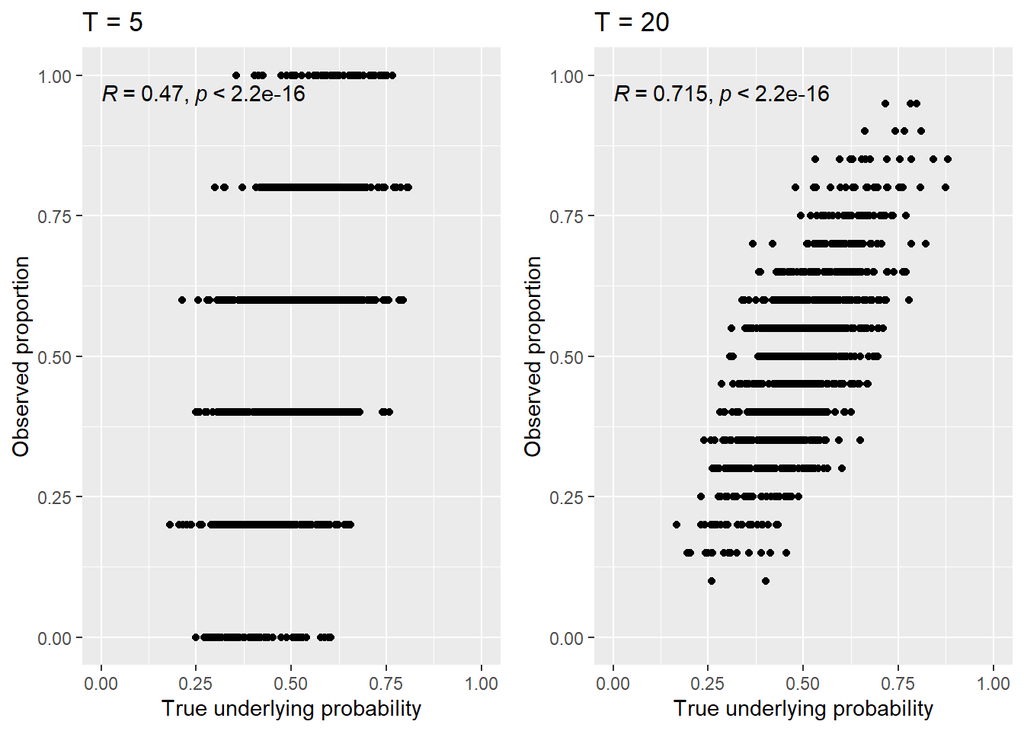

```r
### 2 generate binary X and continuous Y
data_binx_contyt5 <- glmm_data_generation(N_total = 1000, T_total = 5, predictor.type = "binary", outcome.type = "continuous",
                                        sdX.within = NA, sdX.between = 0.5, g.00 = 0, g.01 = 2, sd.u0 = 0.7,
                                        g.10 = 0.5, sd.u1 = 0, sd.e = 0.5)

# only keep level 2 variables
data_binx_contyt5 <- data_binx_contyt5 %>% select(Cluster, X.cluster.means, X.mean.j, p.X.mean.j, eta, b0, b1) %>%
  distinct(Cluster, .keep_all = TRUE)

data_binx_contyt20 <- glmm_data_generation(N_total = 1000, T_total = 20, predictor.type = "binary", outcome.type = "continuous",
                                        sdX.within = NA, sdX.between = 0.5, g.00 = 0, g.01 = 2, sd.u0 = 0.7,
                                        g.10 = 0.5, sd.u1 = 0, sd.e = 0.5)

# only keep level 2 variables
data_binx_contyt20 <- data_binx_contyt20 %>% select(Cluster, X.cluster.means, X.mean.j, p.X.mean.j, eta, b0, b1) %>%
  distinct(Cluster, .keep_all = TRUE)

# scatterplot of p.X.mean.j and b0, b0 and eta, estimated cluster mean and p.X.mean.j
p2.33t5 <- ggplot(data_binx_contyt5, aes(x = p.X.mean.j, y = X.cluster.means)) + geom_point() + labs(title = "T = 5", x = "True underlying probability", y = "Observed proportion") + xlim(0,1) + ylim(0,1) + stat_cor(method = "pearson", digits = 3)
p2.33t20 <- ggplot(data_binx_contyt20, aes(x = p.X.mean.j, y = X.cluster.means)) + geom_point() + labs(title = "T = 20", x = "True underlying probability", y = "Observed proportion") + xlim(0,1) + ylim(0,1) + stat_cor(method = "pearson", digits = 3)

# combine plots
gridExtra::grid.arrange(p2.33t5, p2.33t20, ncol = 2)
```

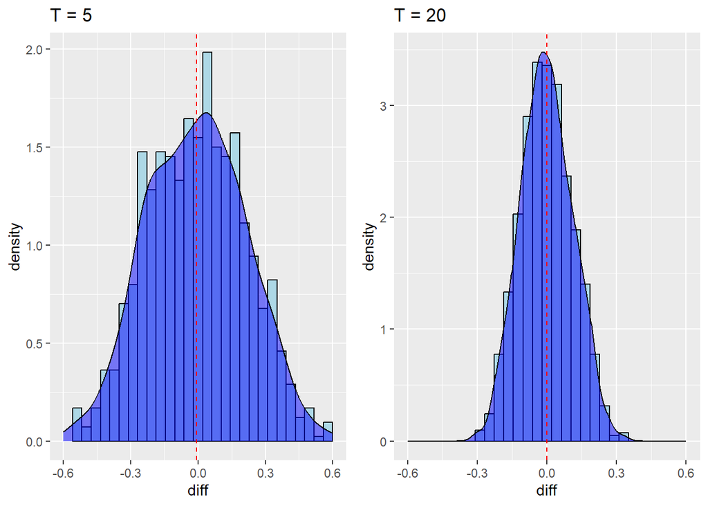

```r
# compute difference between estimated and true cluster mean for each cluster
data_binx_contyt5$diff <- data_binx_contyt5$X.cluster.means - data_binx_contyt5$p.X.mean.j

# plot histogram of differences
p2.42t5 <- ggplot(data_binx_contyt5, aes(x = diff)) + geom_histogram(aes(y = ..density..), bins = 30, fill = "lightblue", color = "black") +
  geom_density(alpha = 0.5, fill = "blue") + labs(title = "T = 5") +
  geom_vline(xintercept = mean(data_binx_contyt5$diff), linetype = "dashed", color = "red") + xlim(-0.6, 0.6)

# compute difference between estimated and true cluster mean for each cluster
data_binx_contyt20$diff <- data_binx_contyt20$X.cluster.means - data_binx_contyt20$p.X.mean.j

# plot histogram of differences
p2.42t20 <- ggplot(data_binx_contyt20, aes(x = diff)) + geom_histogram(aes(y = ..density..), bins = 30, fill = "lightblue", color = "black") +
  geom_density(alpha = 0.5, fill = "blue") + labs(title = "T = 20") +
  geom_vline(xintercept = mean(data_binx_contyt20$diff), linetype = "dashed", color = "red") + xlim(-0.6, 0.6)

# combine plots
gridExtra::grid.arrange(p2.42t5, p2.42t20, ncol = 2)
```

```r
data_binx_contyt20 <- glmm_data_generation(N_total = 5000, T_total = 30, predictor.type = "binary", outcome.type = "continuous",
                                        sdX.within = NA, sdX.between = 0.5, g.00 = 0, g.01 = 2, sd.u0 = 0.7,
                                        g.10 = 0.5, sd.u1 = 0, sd.e = 0.5)

str(data_binx_contyt20)
```

```
'data.frame':   150000 obs. of  12 variables:
 $ Cluster        : int  1 1 1 1 1 1 1 1 1 1 ...
 $ Time           : int  1 2 3 4 5 6 7 8 9 10 ...
 $ X.mean.j       : num  -0.521 -0.521 -0.521 -0.521 -0.521 ...
 $ b0             : num  0.407 0.407 0.407 0.407 0.407 ...
 $ b1             : num  0.5 0.5 0.5 0.5 0.5 0.5 0.5 0.5 0.5 0.5 ...
 $ p.X.mean.j     : num  0.373 0.373 0.373 0.373 0.373 ...
 $ X              : int  0 0 1 0 1 1 0 0 0 0 ...
 $ eta            : num  0.22 0.22 0.72 0.22 0.72 ...
 $ Y              : num  0.57 -0.286 0.855 0.197 0.479 ...
 $ p.Y            : logi  NA NA NA NA NA NA ...
 $ X.cluster.means: num  0.333 0.333 0.333 0.333 0.333 ...
 $ X.cent         : num  -0.333 -0.333 0.667 -0.333 0.667 ...
```

```r
fixef(lmer(Y ~ X + p.X.mean.j + (1 | Cluster), data = data_binx_contyt20))
```

```
(Intercept)           X  p.X.mean.j
 0.01012329  0.50651790  1.44754800
```

## Continuous X and Binary Y

```r
### 3 generate continuous X and binary Y ###
data_contx_biny <- glmm_data_generation(N_total = 1000, T_total = 20, predictor.type = "continuous", outcome.type = "binary",
                                        sdX.within = 0.25, sdX.between = 0.5, g.00 = 0, g.01 = 1, sd.u0 = 0.7,
                                        g.10 = 0.5, sd.u1 = 0, sd.e = NA)

summary(data_contx_biny)
```

```
    Cluster            Time          X.mean.j               b0
 Min.   :   1.0   Min.   : 1.00   Min.   :-1.443514   Min.   :-3.03594
 1st Qu.: 250.8   1st Qu.: 5.75   1st Qu.:-0.340525   1st Qu.:-0.59526
 Median : 500.5   Median :10.50   Median : 0.013025   Median :-0.03432
 Mean   : 500.5   Mean   :10.50   Mean   : 0.008968   Mean   :-0.01040
 3rd Qu.: 750.2   3rd Qu.:15.25   3rd Qu.: 0.345728   3rd Qu.: 0.56200
 Max.   :1000.0   Max.   :20.00   Max.   : 1.563164   Max.   : 2.81596
       b1      p.X.mean.j           X                 eta
 Min.   :0.5   Mode:logical   Min.   :-2.05674   Min.   :-3.301256
 1st Qu.:0.5   NA's:20000     1st Qu.:-0.37396   1st Qu.:-0.599575
 Median :0.5                  Median : 0.01075   Median :-0.031666
 Mean   :0.5                  Mean   : 0.01080   Mean   :-0.009481
 3rd Qu.:0.5                  3rd Qu.: 0.38508   3rd Qu.: 0.572571
 Max.   :0.5                  Max.   : 2.07339   Max.   : 2.983309
       Y              p.Y          X.cluster.means        X.cent
 Min.   :0.000   Min.   :0.03553   Min.   :-1.51354   Min.   :-0.9500514
 1st Qu.:0.000   1st Qu.:0.35444   1st Qu.:-0.34449   1st Qu.:-0.1632165
 Median :0.000   Median :0.49208   Median : 0.01593   Median :-0.0006644
 Mean   :0.499   Mean   :0.49720   Mean   : 0.01080   Mean   : 0.0000000
 3rd Qu.:1.000   3rd Qu.:0.63936   3rd Qu.: 0.34161   3rd Qu.: 0.1649323
 Max.   :1.000   Max.   :0.95181   Max.   : 1.58310   Max.   : 0.9150817
```

```r
fixef(glmer(Y ~ X.cent + X.cluster.means + (1 | Cluster), data = data_contx_biny, family = binomial(link = "logit")))
```

```
    (Intercept)          X.cent X.cluster.means
     -0.0164174       0.4474957       1.0490280
```

```r
# I lowered the values until the range of eta was approximately -3 to 3, roughly corresponding to probabilities of 0.05 to 0.95.
# This was done to ensure that the probabilities are not too close to 0 or 1, which would make the logit transformation unstable.
```

For this scenario, since we have a continuous predictor X, we can set the value of g.01 to be greater than before.

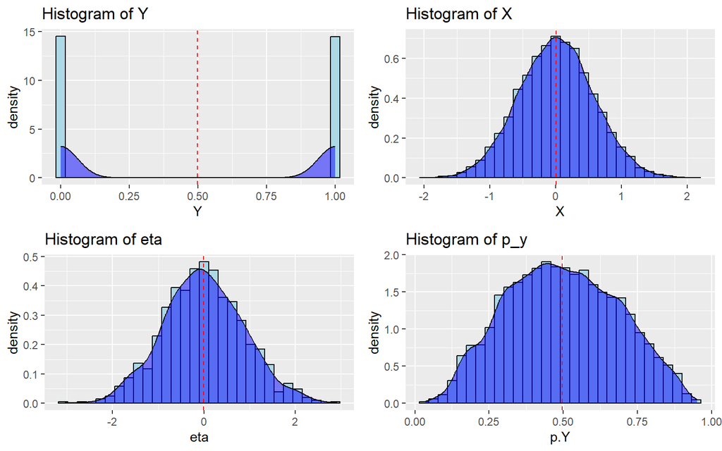

```r
# 3.1 check distributions of X and Y
p3.11 <- ggplot(data_contx_biny, aes(x = Y)) + geom_histogram(aes(y = ..density..), bins = 30, fill = "lightblue", color = "black") +
  geom_density(alpha = 0.5, fill = "blue") + labs(title = "Histogram of Y") +
  geom_vline(xintercept = mean(data_contx_biny$Y), linetype = "dashed", color = "red")
p3.12 <- ggplot(data_contx_biny, aes(x = X)) + geom_histogram(aes(y = ..density..), bins = 30, fill = "lightblue", color = "black") +
  geom_density(alpha = 0.5, fill = "blue") + labs(title = "Histogram of X") +
  geom_vline(xintercept = mean(data_contx_biny$X), linetype = "dashed", color = "red")

# only keep level 2 variables
data_contx_biny_level2 <- data_contx_biny %>% select(Cluster, X.cluster.means, X.mean.j, p.X.mean.j, eta, b0, b1) %>%
  distinct(Cluster, .keep_all = TRUE)

# 3.2 check distributions of eta and p_y
p3.21 <- ggplot(data_contx_biny_level2, aes(x = eta)) + geom_histogram(aes(y = ..density..), bins = 30, fill = "lightblue", color = "black") +
  geom_density(alpha = 0.5, fill = "blue") + labs(title = "Histogram of eta") +
  geom_vline(xintercept = mean(data_contx_biny$eta), linetype = "dashed", color = "red")
p3.22 <- ggplot(data_contx_biny, aes(x = p.Y)) + geom_histogram(aes(y = ..density..), bins = 30, fill = "lightblue", color = "black") +
  geom_density(alpha = 0.5, fill = "blue") + labs(title = "Histogram of p_y") +
  geom_vline(xintercept = mean(data_contx_biny$p.Y), linetype = "dashed", color = "red")

# combine plots
gridExtra::grid.arrange(p3.11, p3.12, p3.21, p3.22, ncol = 2)
```

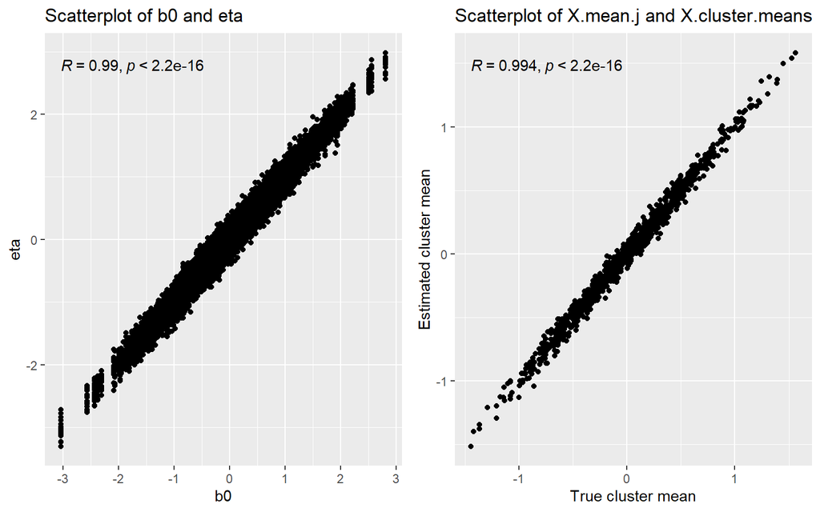

```r
# 3.3 scatterplot of b0 and eta and X.mean.j and X.cluster.means
p3.31 <- ggplot(data_contx_biny, aes(x = b0, y = eta)) + geom_point() + labs(title = "Scatterplot of b0 and eta") + stat_cor(method = "pearson", digits = 3)
p3.32 <- ggplot(data_contx_biny, aes(x = X.mean.j, y = X.cluster.means)) + geom_point() + labs(title = "Scatterplot of X.mean.j and X.cluster.means", x = "True cluster mean", y = "Estimated cluster mean") + stat_cor(method = "pearson", digits = 3)

# combine plots
gridExtra::grid.arrange(p3.31, p3.32, ncol = 2)
```

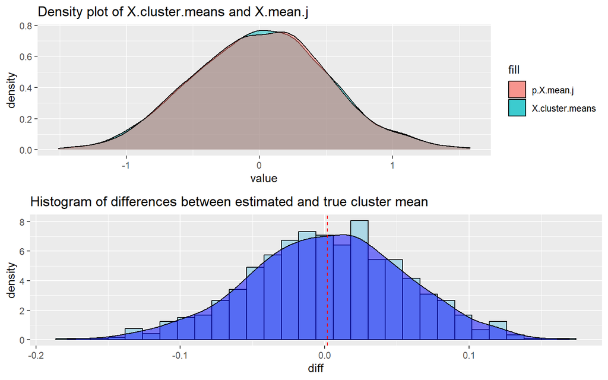

```r
# create overlapping density plots for X.cluster.means and p.X.mean.j
p3.41 <- ggplot(data_contx_biny_level2, aes(x = X.cluster.means, fill = "X.cluster.means")) + geom_density(alpha = 0.5) +
  geom_density(aes(x = X.mean.j, fill = "p.X.mean.j"), alpha = 0.5) + labs(title = "Density plot of X.cluster.means and X.mean.j", x = "value")

# compute difference between estimated and true cluster mean for each cluster
data_contx_biny_level2$diff <- data_contx_biny_level2$X.cluster.means - data_contx_biny_level2$X.mean.j

# plot histogram of differences
p3.42 <- ggplot(data_contx_biny_level2, aes(x = diff)) + geom_histogram(aes(y = ..density..), bins = 30, fill = "lightblue", color = "black") +
  geom_density(alpha = 0.5, fill = "blue") + labs(title = "Histogram of differences between estimated and true cluster mean") +
  geom_vline(xintercept = mean(data_contx_biny_level2$diff), linetype = "dashed", color = "red")

# combine plots
gridExtra::grid.arrange(p3.41, p3.42, nrow = 2)
```

## Binary X and Y

```r
# 4 generate binary X and Y
data_binary <- glmm_data_generation(N_total = 1000, T_total = 20, predictor.type = "binary", outcome.type = "binary",
                                    sdX.within = NA, sdX.between = 0.5, g.00 = 0, g.01 = 0.6, sd.u0 = 0.7,
                                    g.10 = 0.5, sd.u1 = 0, sd.e = NA)

summary(data_binary)
```

```
    Cluster            Time          X.mean.j               b0
 Min.   :   1.0   Min.   : 1.00   Min.   :-1.609989   Min.   :-1.7092
 1st Qu.: 250.8   1st Qu.: 5.75   1st Qu.:-0.348260   1st Qu.:-0.1639
 Median : 500.5   Median :10.50   Median : 0.013911   Median : 0.3131
 Mean   : 500.5   Mean   :10.50   Mean   :-0.004395   Mean   : 0.3143
 3rd Qu.: 750.2   3rd Qu.:15.25   3rd Qu.: 0.330849   3rd Qu.: 0.7892
 Max.   :1000.0   Max.   :20.00   Max.   : 2.040542   Max.   : 2.3267
       b1        p.X.mean.j           X               eta
 Min.   :0.5   Min.   :0.1666   Min.   :0.0000   Min.   :-1.8615
 1st Qu.:0.5   1st Qu.:0.4138   1st Qu.:0.0000   1st Qu.:-0.1988
 Median :0.5   Median :0.5035   Median :0.0000   Median : 0.3284
 Mean   :0.5   Mean   :0.4991   Mean   :0.4978   Mean   : 0.3137
 3rd Qu.:0.5   3rd Qu.:0.5820   3rd Qu.:1.0000   3rd Qu.: 0.8410
 Max.   :0.5   Max.   :0.8850   Max.   :1.0000   Max.   : 2.5905
       Y               p.Y         X.cluster.means      X.cent
 Min.   :0.0000   Min.   :0.1345   Min.   :0.0500   Min.   :-0.95
 1st Qu.:0.0000   1st Qu.:0.4505   1st Qu.:0.4000   1st Qu.:-0.45
 Median :1.0000   Median :0.5814   Median :0.5000   Median :-0.10
 Mean   :0.5699   Mean   :0.5694   Mean   :0.4978   Mean   : 0.00
 3rd Qu.:1.0000   3rd Qu.:0.6987   3rd Qu.:0.6000   3rd Qu.: 0.45
 Max.   :1.0000   Max.   :0.9302   Max.   :0.9500   Max.   : 0.95
```

```r
fixef(glmer(Y ~ X.cent + X.cluster.means + (1 | Cluster), data = data_binary, family = binomial(link = "logit")))
```

```
    (Intercept)          X.cent X.cluster.means
     0.03692204      0.58233160      0.56191595
```

```r
# similar to (3), I lowered the values until the range of eta was approximately -3 to 3, roughly corresponding to probabilities of 0.05 to 0.95.
# In addition, I made sure eta was centered approximately at 0 to ensure balanced probabilities (mean of 0.5)
```

As with the scenario with a binary predictor X and continuous outcome Y, we have to manage the size of g.01 to ensure that the estimation is stable. A value of 0.6 seems to be fine.

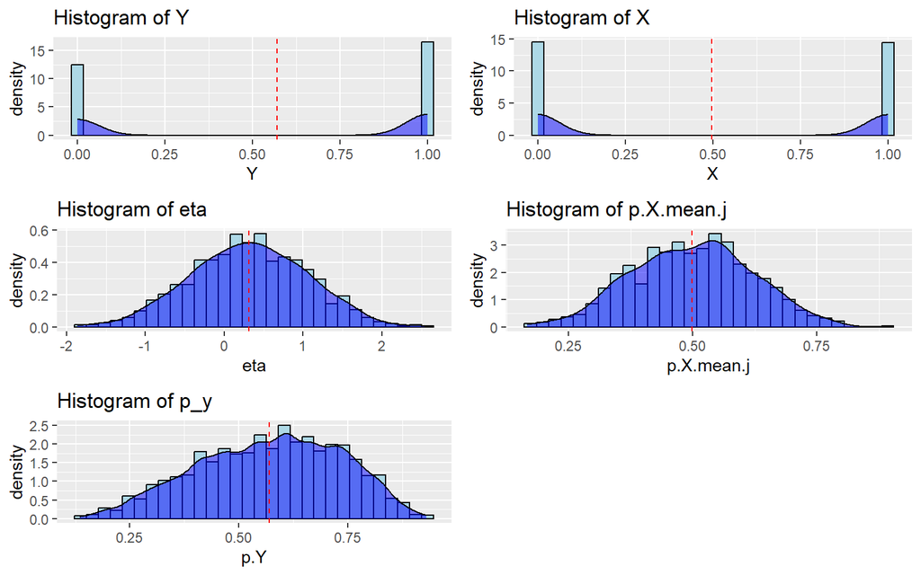

```r
# 4.1 check distributions of X and Y
p4.11 <- ggplot(data_binary, aes(x = Y)) + geom_histogram(aes(y = ..density..), bins = 30, fill = "lightblue", color = "black") +
  geom_density(alpha = 0.5, fill = "blue") + labs(title = "Histogram of Y") +
  geom_vline(xintercept = mean(data_binary$Y), linetype = "dashed", color = "red")
p4.12 <- ggplot(data_binary, aes(x = X)) + geom_histogram(aes(y = ..density..), bins = 30, fill = "lightblue", color = "black") +
  geom_density(alpha = 0.5, fill = "blue") + labs(title = "Histogram of X") +
  geom_vline(xintercept = mean(data_binary$X), linetype = "dashed", color = "red")

# only keep level 2 variables
data_binary_level2 <- data_binary %>% select(Cluster, X.cluster.means, X.mean.j, p.X.mean.j, eta, b0, b1) %>%
  distinct(Cluster, .keep_all = TRUE)

# 4.2 histograms with density overlay for evaluation of probability distributions
p4.21 <- ggplot(data_binary_level2, aes(x = eta)) + geom_histogram(aes(y = ..density..), bins = 30, fill = "lightblue", color = "black") +
  geom_density(alpha = 0.5, fill = "blue") + labs(title = "Histogram of eta") +
  geom_vline(xintercept = mean(data_binary$eta), linetype = "dashed", color = "red")
p4.22 <- ggplot(data_binary_level2, aes(x = p.X.mean.j)) + geom_histogram(aes(y = ..density..), bins = 30, fill = "lightblue", color = "black") +
  geom_density(alpha = 0.5, fill = "blue") + labs(title = "Histogram of p.X.mean.j") +
  geom_vline(xintercept = mean(data_binary$p.X.mean.j), linetype = "dashed", color = "red")
p4.23 <- ggplot(data_binary, aes(x = p.Y)) + geom_histogram(aes(y = ..density..), bins = 30, fill = "lightblue", color = "black") +
  geom_density(alpha = 0.5, fill = "blue") + labs(title = "Histogram of p_y") +
  geom_vline(xintercept = mean(data_binary$p.Y), linetype = "dashed", color = "red")

# when sdX.between is large (e.g, sqrt(4)) the distribution of probabilities
# of X and Y are U/bowl shaped (higher density at the edges)
# when sdX.between is small (e.g., sqrt(0.4)) the distribution of probabilities
# of X and Y are inverted U shaped (higher density in the center)
# when sdX.between is moderate (e.g., sqrt(2)) the distribution of probabilities
# is more uniform but inverted U shaped for X and slightly U shaped for Y.

# combine plots
gridExtra::grid.arrange(p4.11, p4.12, p4.21, p4.22, p4.23, ncol = 2)
```

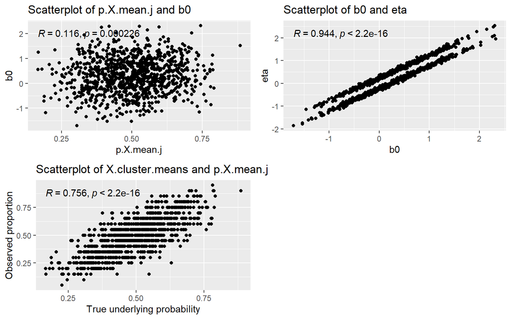

```r
# 4.3 scatterplots for evaluation of relationship between probabilities and originating variables

# between p.X.mean.j and b0
p4.31 <- ggplot(data_binary_level2, aes(x = p.X.mean.j, y = b0)) + geom_point() + labs(title = "Scatterplot of p.X.mean.j and b0") + stat_cor(method = "pearson", digits = 3)

# between b0 and eta
p4.32 <- ggplot(data_binary_level2, aes(x = b0, y = eta)) + geom_point() + labs(title = "Scatterplot of b0 and eta") + stat_cor(method = "pearson", digits = 3)

# between X.cluster.means and p.X.mean.j
p4.33 <- ggplot(data_binary_level2, aes(x = p.X.mean.j, y = X.cluster.means)) + geom_point() + labs(title = "Scatterplot of X.cluster.means and p.X.mean.j", x = "True underlying probability", y = "Observed proportion") + stat_cor(method = "pearson", digits = 3)

# combine plots
gridExtra::grid.arrange(p4.31, p4.32, p4.33, ncol = 2)
```

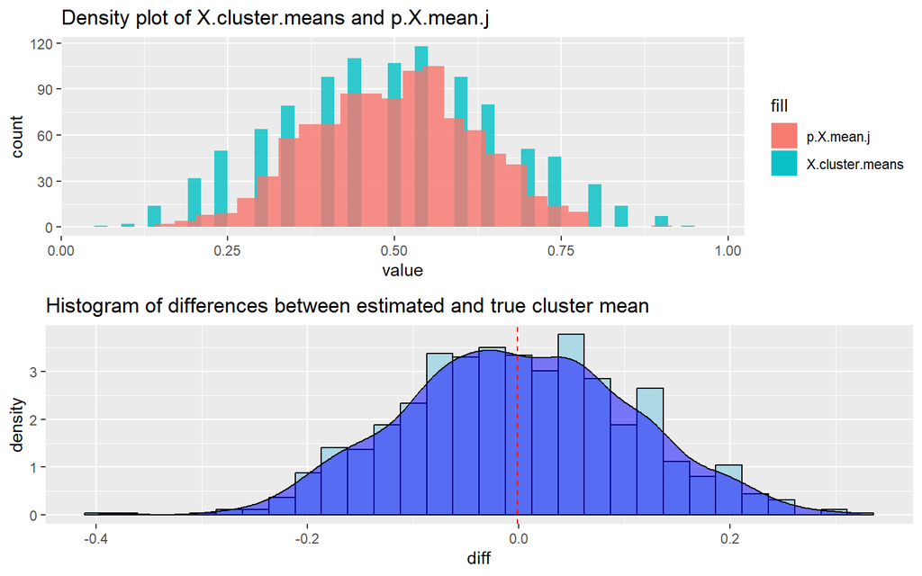

```r
# Other: plots below only really indicate logit relationship
# ggplot(data_binary, aes(x = X.mean.j, y = p.X.mean.j)) + geom_point() + labs(title = "Scatterplot of X.mean.j and p.X.mean.j")
# As expected, we see a a sigmoid curve representing the logit relationship between X.mean.j
# and p.X.mean.j. It is more pronounced (different from linear) when sdX.between is large.

# ggplot(data_binary, aes(x = eta, y = p.Y)) + geom_point() + labs(title = "Scatterplot of eta and p_y")
# As expected again, we see a sigmoid curve representing the logit relationship between eta
# and p_y. It is more pronounced (different from linear) when sdX.between and sd.u0 are large.

# create overlapping density plots for X.cluster.means and p.X.mean.j
p4.41 <- ggplot(data_binary_level2, aes(x = X.cluster.means, fill = "X.cluster.means")) + geom_histogram(alpha = 0.8, binwidth = 0.02) +
  geom_histogram(aes(x = p.X.mean.j, fill = "p.X.mean.j"), alpha = 0.8) + labs(title = "Density plot of X.cluster.means and p.X.mean.j", x = "value")

# compute difference between estimated and true cluster mean for each cluster
data_binary_level2$diff <- data_binary_level2$X.cluster.means - data_binary_level2$p.X.mean.j

# plot histogram of differences
p4.42 <- ggplot(data_binary_level2, aes(x = diff)) + geom_histogram(aes(y = ..density..), bins = 30, fill = "lightblue", color = "black") +
  geom_density(alpha = 0.5, fill = "blue") + labs(title = "Histogram of differences between estimated and true cluster mean") +
  geom_vline(xintercept = mean(data_binary_level2$diff), linetype = "dashed", color = "red")

# combine plots
gridExtra::grid.arrange(p4.41, p4.42, nrow = 2)
```

Let us now simulate the data with a more U shaped distribution for p.X.mean.j by increasing the value of sdX.between from 0.5 to 3.

```r
# 4 generate binary X and Y
data_binary <- glmm_data_generation(N_total = 1000, T_total = 20, predictor.type = "binary", outcome.type = "binary",
                                    sdX.within = NA, sdX.between = 3, g.00 = 0, g.01 = 0.6, sd.u0 = 0.7,
                                    g.10 = 0.5, sd.u1 = 0, sd.e = NA)

summary(data_binary)
```

```
    Cluster            Time          X.mean.j               b0
 Min.   :   1.0   Min.   : 1.00   Min.   :-7.734220   Min.   :-2.3886
 1st Qu.: 250.8   1st Qu.: 5.75   1st Qu.:-1.903051   1st Qu.:-0.1810
 Median : 500.5   Median :10.50   Median :-0.155882   Median : 0.3225
 Mean   : 500.5   Mean   :10.50   Mean   : 0.001057   Mean   : 0.3108
 3rd Qu.: 750.2   3rd Qu.:15.25   3rd Qu.: 2.006393   3rd Qu.: 0.8092
 Max.   :1000.0   Max.   :20.00   Max.   : 8.486502   Max.   : 2.9726
       b1        p.X.mean.j              X               eta
 Min.   :0.5   Min.   :0.0004374   Min.   :0.0000   Min.   :-2.4437
 1st Qu.:0.5   1st Qu.:0.1297635   1st Qu.:0.0000   1st Qu.:-0.2113
 Median :0.5   Median :0.4611086   Median :0.0000   Median : 0.3099
 Mean   :0.5   Mean   :0.4936507   Mean   :0.4943   Mean   : 0.3111
 3rd Qu.:0.5   3rd Qu.:0.8814667   3rd Qu.:1.0000   3rd Qu.: 0.8169
 Max.   :0.5   Max.   :0.9997938   Max.   :1.0000   Max.   : 3.0274
       Y               p.Y         X.cluster.means      X.cent
 Min.   :0.0000   Min.   :0.0799   Min.   :0.0000   Min.   :-0.95
 1st Qu.:0.0000   1st Qu.:0.4474   1st Qu.:0.1500   1st Qu.:-0.15
 Median :1.0000   Median :0.5769   Median :0.4500   Median : 0.00
 Mean   :0.5662   Mean   :0.5688   Mean   :0.4943   Mean   : 0.00
 3rd Qu.:1.0000   3rd Qu.:0.6936   3rd Qu.:0.9000   3rd Qu.: 0.15
 Max.   :1.0000   Max.   :0.9538   Max.   :1.0000   Max.   : 0.95
```

```r
fixef(glmer(Y ~ X.cent + X.cluster.means + (1 | Cluster), data = data_binary, family = binomial(link = "logit")))
```

```
    (Intercept)          X.cent X.cluster.means
    0.008022018     0.455880296     0.585572887
```

```r
# similar to (3), I lowered the values until the range of eta was approximately -3 to 3, roughly corresponding to probabilities of 0.05 to 0.95.
# In addition, I made sure eta was centered approximately at 0 to ensure balanced probabilities (mean of 0.5)
```

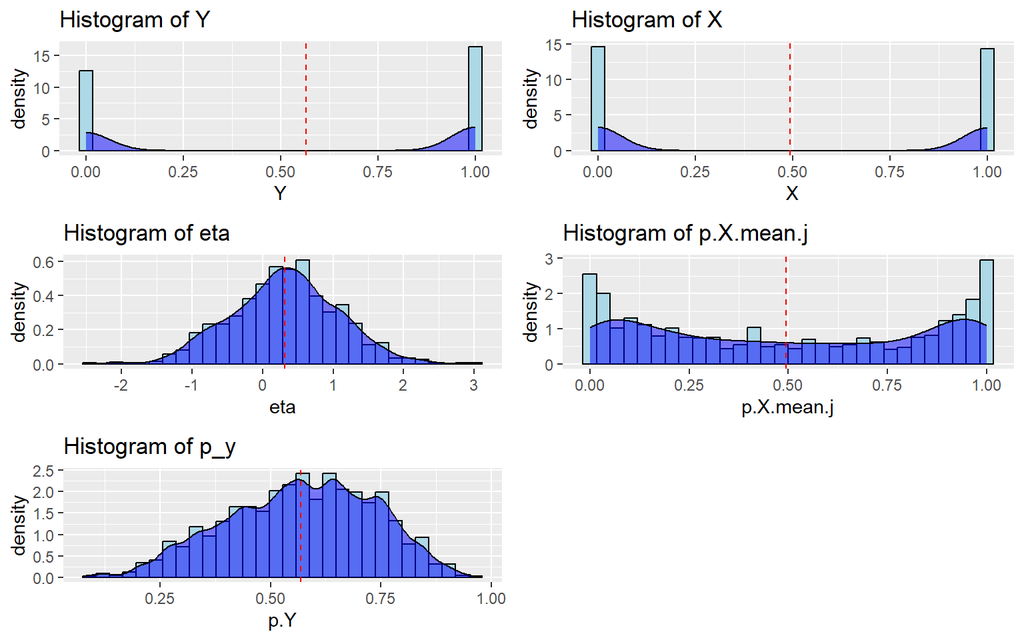

```r
# 4.1 check distributions of X and Y
p4.11 <- ggplot(data_binary, aes(x = Y)) + geom_histogram(aes(y = ..density..), bins = 30, fill = "lightblue", color = "black") +
  geom_density(alpha = 0.5, fill = "blue") + labs(title = "Histogram of Y") +
  geom_vline(xintercept = mean(data_binary$Y), linetype = "dashed", color = "red")
p4.12 <- ggplot(data_binary, aes(x = X)) + geom_histogram(aes(y = ..density..), bins = 30, fill = "lightblue", color = "black") +
  geom_density(alpha = 0.5, fill = "blue") + labs(title = "Histogram of X") +
  geom_vline(xintercept = mean(data_binary$X), linetype = "dashed", color = "red")

# only keep level 2 variables
data_binary_level2 <- data_binary %>% select(Cluster, X.cluster.means, X.mean.j, p.X.mean.j, eta, b0, b1) %>%
  distinct(Cluster, .keep_all = TRUE)

# 4.2 histograms with density overlay for evaluation of probability distributions
p4.21 <- ggplot(data_binary_level2, aes(x = eta)) + geom_histogram(aes(y = ..density..), bins = 30, fill = "lightblue", color = "black") +
  geom_density(alpha = 0.5, fill = "blue") + labs(title = "Histogram of eta") +
  geom_vline(xintercept = mean(data_binary$eta), linetype = "dashed", color = "red")
p4.22 <- ggplot(data_binary_level2, aes(x = p.X.mean.j)) + geom_histogram(aes(y = ..density..), bins = 30, fill = "lightblue", color = "black") +
  geom_density(alpha = 0.5, fill = "blue") + labs(title = "Histogram of p.X.mean.j") +
  geom_vline(xintercept = mean(data_binary$p.X.mean.j), linetype = "dashed", color = "red")
p4.23 <- ggplot(data_binary, aes(x = p.Y)) + geom_histogram(aes(y = ..density..), bins = 30, fill = "lightblue", color = "black") +
  geom_density(alpha = 0.5, fill = "blue") + labs(title = "Histogram of p_y") +
  geom_vline(xintercept = mean(data_binary$p.Y), linetype = "dashed", color = "red")

# when sdX.between is large (e.g, sqrt(4)) the distribution of probabilities
# of X and Y are U/bowl shaped (higher density at the edges)
# when sdX.between is small (e.g., sqrt(0.4)) the distribution of probabilities
# of X and Y are inverted U shaped (higher density in the center)
# when sdX.between is moderate (e.g., sqrt(2)) the distribution of probabilities
# is more uniform but inverted U shaped for X and slightly U shaped for Y.

# combine plots
gridExtra::grid.arrange(p4.11, p4.12, p4.21, p4.22, p4.23, ncol = 2)
```